# Exploratorio NO supervisado

María Sánchez Vivo

2026-05-05

# **Introducción**

El script realiza un análisis multiómico integrado con el objetivo de caracterizar la relación entre microbiota, metabolitos y variables clínicas en distintos grupos de diagnóstico. Para ello, se integran y depuran múltiples fuentes de datos (metagenómica, metabolómica y clínica) en un marco común de análisis, donde se construyen objetos estructurados para microbiota y se armonizan las matrices de variables.

A nivel exploratorio, se aplican **técnicas de reducción de dimensionalidad lineales** y **no lineales (PCA, PCoA, UMAP y t-SNE)** tanto en metabolitos como en variables clínicas y datos microbianos, complementadas con métricas de distancia adecuadas para cada tipo de dato **(Bray-Curtis, euclidiana y Gower)**. Paralelamente, se evalúan diferencias entre grupos clínicos mediante pruebas **PERMANOVA**.

Finalmente, los resultados se integran en visualizaciones avanzadas como **heatmaps basados en variables seleccionadas por PCA** y **asociaciones estadísticas (V de Cramer)**, lo que permite identificar patrones conjuntos de variación biológica asociados al estado clínico y facilitar su interpretación global.

# **Carga de librerías, datos y preparación inicial**

Se cargan las librerías necesarias para el análisis multiómico y se importan los distintos conjuntos de datos (metabolitos, microbiota y variables clínicas) que posteriormente se integran en un único marco de trabajo. Además, se realiza una limpieza inicial de variables clínicas, se combinan con los metabolitos y se definen las variables categóricas y numéricas, así como la paleta de colores asociada a los distintos diagnósticos para su uso en los análisis y visualizaciones posteriores.

```r
library(FactoMineR)
library(factoextra)
library(uwot)
library(Rtsne)
library(cluster)
library(ggpubr)
library(ggrepel)
library(ComplexHeatmap)
library(circlize)
library(mia)
library(miaViz)
library(vegan)
library(scater)
library(tidyverse)
library(RColorBrewer)

datos_metabolitos      <- readRDS("metabolitos.rds")
datos_metataxonomicos  <- readRDS("tax.rds")
datos_clinicos         <- readRDS("covs.rds")
datos_abundancia_16S   <- readRDS("metagen.rds")

# Reconstruir datos_clinicos_metabolomicos
datos_clinicos_limpios <- datos_clinicos %>%
  as.data.frame() %>%
  select(-ends_with("_0"))

datos_clinicos_metabolomicos <- merge(datos_clinicos_limpios,
                                      datos_metabolitos,
                                      by = "Sample")

nombres_metabolitos <- names(datos_metabolitos)[names(datos_metabolitos) != "Sample"]

vars_id <- c("Sample", "diagnostico_principal")

vars_cat <- datos_clinicos_metabolomicos %>%
  select(-all_of(vars_id), -all_of(nombres_metabolitos)) %>%
  select(where(~ is.factor(.) | is.character(.))) %>%
  select(where(~ n_distinct(., na.rm = TRUE) >= 2)) %>%
  names()

vars_num <- datos_clinicos_metabolomicos %>%
  select(-all_of(vars_id), -all_of(nombres_metabolitos)) %>%
  select(where(is.numeric)) %>%
  select(where(~ n_distinct(., na.rm = TRUE) >= 2)) %>%
  names()

paleta_dx <- c("CBP"     = "#E41A1C",
               "Healthy" = "#4DAF4A",
               "HAI"     = "#377EB8",
               "VHC"     = "#FF7F00")
```

## **Construcción del objeto de análisis microbiológico**

Se integran los datos de abundancia microbiana, taxonomía y variables clínicas en un objeto de tipo **TreeSummarizedExperiment**, asegurando la correcta alineación de muestras y taxones. Posteriormente, se transforma la tabla a **abundancia relativa** y se agrupan los **datos a nivel de género**, con el objetivo de facilitar los análisis exploratorios y comparativos.

```r
# Reconstruir TSE
counts_prepared <- datos_abundancia_16S %>%
  column_to_rownames("Sample") %>%
  t() %>%
  as.matrix()
colnames(counts_prepared) <- trimws(colnames(counts_prepared))

datos_clinicos_mia <- as.data.frame(datos_clinicos)
rownames(datos_clinicos_mia) <- trimws(as.character(datos_clinicos_mia$Sample))

tax_prepared <- datos_metataxonomicos %>%
  as.data.frame() %>%
  as.matrix()
rownames(tax_prepared) <- trimws(rownames(tax_prepared))

comun_muestras  <- intersect(colnames(counts_prepared), rownames(datos_clinicos_mia))
counts_filtrado <- counts_prepared[, comun_muestras]
clinicos_final  <- datos_clinicos_mia[comun_muestras, ]

comun_taxones <- intersect(rownames(counts_filtrado), rownames(tax_prepared))
counts_final  <- counts_filtrado[comun_taxones, ]
tax_final     <- tax_prepared[comun_taxones, ]

tse <- TreeSummarizedExperiment(
  assays  = list(counts = as.matrix(counts_final)),
  colData = DataFrame(clinicos_final),
  rowData = DataFrame(tax_final)
)
tse <- transformAssay(tse, method = "relabundance")

tse_genus <- agglomerateByRank(tse, rank = "Genus")
tse_genus <- tse_genus[rowData(tse_genus)$Genus != "", ]
tse_genus <- transformAssay(tse_genus, method = "relabundance")

cat("Muestras:", nrow(datos_clinicos_metabolomicos), "\n")
```

```
## Muestras: 46
```

```r
cat("Metabolitos:", length(nombres_metabolitos), "\n")
```

```
## Metabolitos: 53
```

```r
cat("Géneros:", nrow(tse_genus), "\n")
```

```
## Géneros: 486
```

# Análisis PCoA de microbiota y PERMANOVA

En este apartado se calcula la **distancia Bray-Curtis** (sobre las abundancias relativas microbianas) y se aplica un **análisis PCoA para explorar la estructura global de la microbiota**. Después, se evalúan las diferencias entre grupos clínicos mediante **PERMANOVA** y se visualizan los resultados mediante elipses que representan la variabilidad por diagnóstico.

```r
tse <- runMDS(tse,
              FUN        = vegan::vegdist,
              method     = "bray",
              assay.type = "relabundance",
              name       = "PCoA_bray")

# PERMANOVA sobre counts
dist_bray <- vegdist(t(assay(tse, "counts")), method = "bray")
set.seed(123)
permanova <- adonis2(dist_bray ~ diagnostico_principal,
                     data         = as.data.frame(colData(tse)),
                     permutations = 999)
print(permanova)
```

```
## Permutation test for adonis under reduced model
## Permutation: free
## Number of permutations: 999
##
## adonis2(formula = dist_bray ~ diagnostico_principal, data = as.data.frame(colData(tse)), permutations = 999)
##          Df SumOfSqs      R2     F Pr(>F)
## Model     3   0.3107 0.05756 0.855  0.662
## Residual 42   5.0879 0.94244
## Total    45   5.3987 1.00000
```

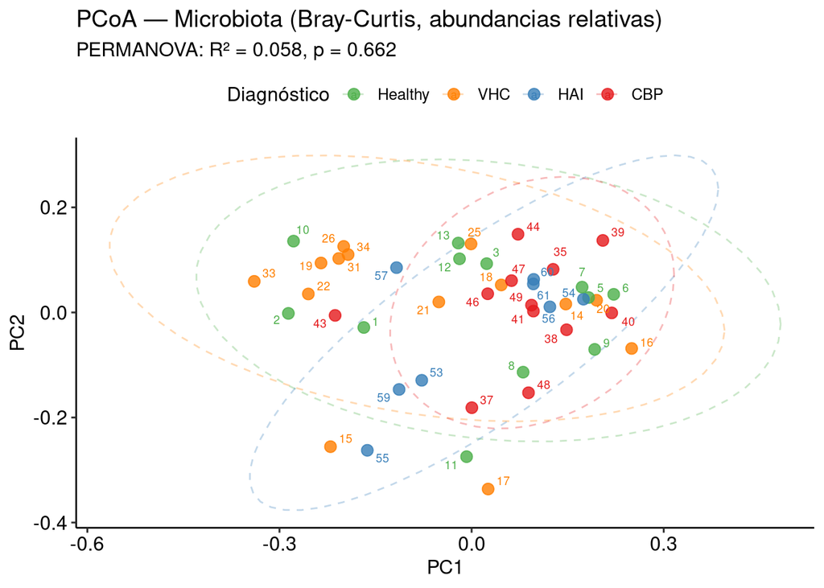

```r
# Extraer coordenadas
pcoa_coords <- reducedDim(tse, "PCoA_bray")
df_pcoa <- data.frame(
  PC1         = pcoa_coords[, 1],
  PC2         = pcoa_coords[, 2],
  diagnostico = factor(colData(tse)$diagnostico_principal),
  SampleID    = colData(tse)$Sample
)

# Elipse con alpha detrás de los puntos, label solo en geom_text_repel
p_pcoa <- ggplot(df_pcoa, aes(x = PC1, y = PC2, color = diagnostico)) +
  stat_ellipse(aes(group = diagnostico), type = "t",        # elipse primero (detrás)
               linetype = "dashed", linewidth = 0.5,
               alpha = 0.3, fill = NA) +
  geom_point(size = 3, alpha = 0.8) +                        # puntos encima
  geom_text_repel(aes(label = SampleID),                     # label solo aquí
                  size = 2.5, max.overlaps = 10) +
  scale_color_manual(values = paleta_dx) +
  theme_pubr() +
  labs(title    = "PCoA — Microbiota (Bray-Curtis, abundancias relativas)",
       subtitle = paste0("PERMANOVA: R² = ",
                         round(permanova$R2[1], 3),
                         ", p = ", permanova$`Pr(>F)`[1]),
       x = "PC1", y = "PC2", color = "Diagnóstico")
print(p_pcoa)
```

El análisis de **beta-diversidad mediante PERMANOVA** y su visualización en el **PCoA** confirman que **no existen diferencias globales significativas en la composición de la microbiota entre los grupos de diagnóstico** (p = 0.662). Las elipses de confianza se solapan casi por completo en el gráfico, y la variable diagnóstica apenas explica un 5.75% de la variabilidad total observada (R^2 = 0.058), quedando el 94.24% restante asociado a la variabilidad individual (residuos). Este resultado estadístico ratifica la **homogeneidad global** de las muestras y justifica metodológicamente el uso de herramientas de alta sensibilidad, como *ANCOM-BC2* a nivel exploratorio, para poder rescatar aquellos taxones minoritarios específicos que logran romper esta uniformidad general.

# **Metabolitos**

## Análisis PCA de metabolitos y PERMANOVA

A continuación, se estandarizan los metabolitos y se aplica un **PCA** para reducir la dimensionalidad y explorar la variabilidad global del conjunto de datos. Después, se evalúan diferencias entre grupos clínicos mediante **PERMANOVA basada en distancia euclidiana**.

```r
# Escalar siempre los datos numéricos
mat_met <- datos_clinicos_metabolomicos %>%
  select(all_of(nombres_metabolitos)) %>%
  scale()   # scale() siempre para comparativas
rownames(mat_met) <- datos_clinicos_metabolomicos$Sample

# PERMANOVA metabolitos (distancia Euclidiana sobre datos escalados)
dist_eucl_met <- dist(mat_met, method = "euclidean")
set.seed(123)
permanova_met <- adonis2(dist_eucl_met ~ diagnostico_principal,
                         data         = datos_clinicos_metabolomicos,
                         permutations = 999)
cat("=== PERMANOVA Metabolitos (Euclidiana, escalado) ===\n")
```

```
## === PERMANOVA Metabolitos (Euclidiana, escalado) ===
```

```r
print(permanova_met)
```

```
## Permutation test for adonis under reduced model
## Permutation: free
## Number of permutations: 999
##
## adonis2(formula = dist_eucl_met ~ diagnostico_principal, data = datos_clinicos_metabolomicos, permutations = 999)
##          Df SumOfSqs      R2      F Pr(>F)
## Model     3   372.84 0.15633 2.5941  0.001 ***
## Residual 42  2012.16 0.84367
## Total    45  2385.00 1.00000
## ---
## Signif. codes:  0 '***' 0.001 '**' 0.01 '*' 0.05 '.' 0.1 ' ' 1
```

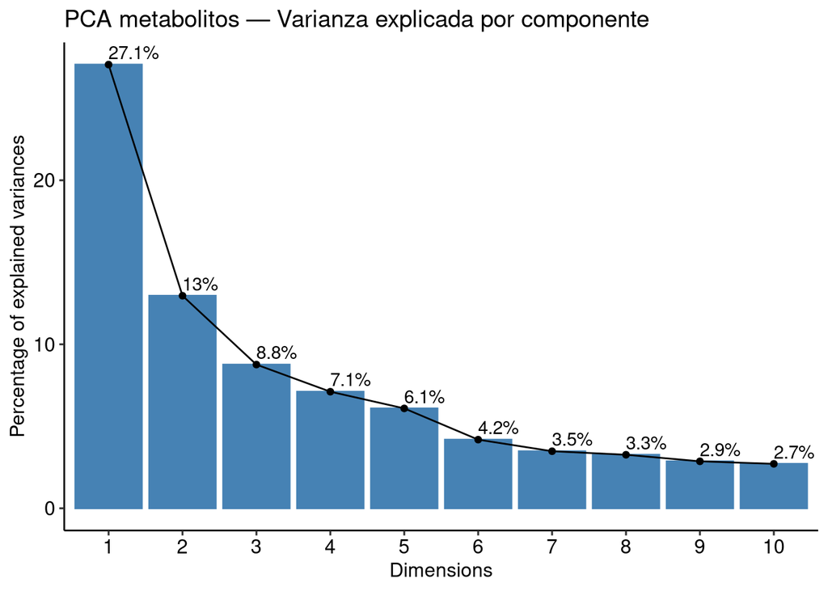

```r
pca_met <- PCA(mat_met, graph = FALSE, ncp = 10)

# Varianza explicada
fviz_eig(pca_met, addlabels = TRUE, ncp = 10) +
  theme_pubr() +
  labs(title = "PCA metabolitos — Varianza explicada por componente")
```

A diferencia de la microbiota (donde no había diferencias globales), el perfil metabolómico **sí separa de forma estadísticamente significativa a los grupos diagnósticos** (p = 0.001). El modelo **PERMANOVA** señala que la patología explica el **15.63% de la variabilidad total** de los metabolitos, una fuerza de asociación casi tres veces mayor que la bacteriana. Además, el *scree plot* del PCA valida el análisis bidimensional al concentrar el **40.1% de la varianza** en las dos primeras dimensiones (Dim 1: 27.1%; Dim 2: 13%), lo que anticipa una separación visual de los pacientes según su enfermedad.

## Visualización PCA de metabolitos

En este apartado se representa la distribución de las muestras en el espacio definido por el **PCA de metabolitos**, incorporando el diagnóstico clínico. Además, se añaden elipses de confianza para visualizar la separación entre grupos.

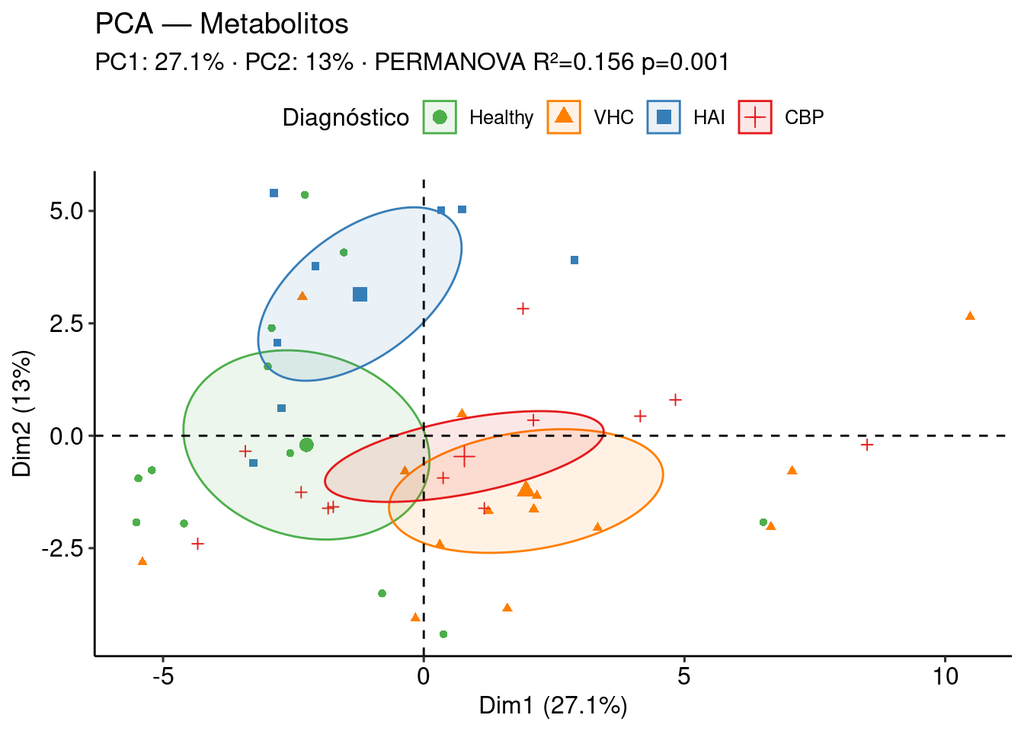

```r
fviz_pca_ind(pca_met,
             col.ind      = datos_clinicos_metabolomicos$diagnostico_principal,
             palette      = paleta_dx,
             addEllipses  = TRUE,
             ellipse.type = "confidence",
             ellipse.alpha = 0.1,
             legend.title = "Diagnóstico",
             repel        = TRUE,
             label        = "none") +
  theme_pubr() +
  labs(title    = "PCA — Metabolitos",
       subtitle = paste0("PC1: ", round(pca_met$eig[1, 2], 1), "% · ",
                         "PC2: ", round(pca_met$eig[2, 2], 1), "% · ",
                         "PERMANOVA R²=", round(permanova_met$R2[1], 3),
                         " p=", permanova_met$`Pr(>F)`[1]))
```

El **score plot del PCA** plasma visualmente la separación significativa confirmada por el PERMANOVA (p=0.001), donde la **Dimensión 1 (27.1%)** divide las muestras horizontalmente al desplazar a **VHC y CBP** hacia la derecha (valores positivos) y mantener a **Healthy y HAI** hacia la izquierda (valores negativos), evidenciando que las dos primeras hepatopatías comparten una firma metabólica muy similar. Por su parte, la **Dimensión 2 (13%)** aporta la especificidad patológica vertical al separar de forma neta la elipse de **HAI** (cuadrante superior) del grupo control **Healthy** (cuadrante inferior). Así, el gráfico demuestra que **HAI presenta el perfil más distante y diferenciado** frente al resto de las enfermedades, confirmando que cada patología induce una huella metabólica plasmática con entidad propia.

## Interpretación de variables en PCA de metabolitos

Después, se identifican los **metabolitos con mayor contribución a los dos primeros componentes principales del PCA**, con el objetivo de interpretar las principales fuentes de variabilidad en los datos.

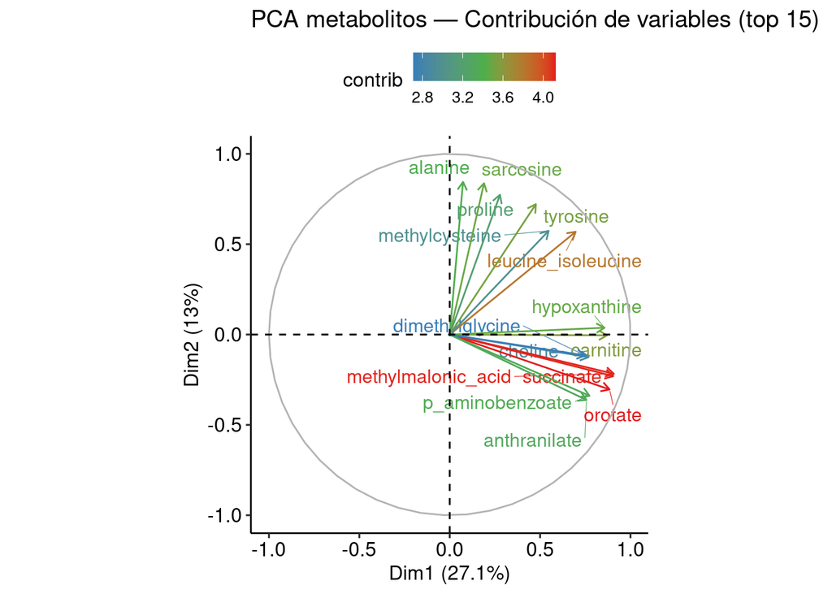

```r
fviz_pca_var(pca_met,
             col.var       = "contrib",
             gradient.cols = c("#377EB8", "#4DAF4A", "#E41A1C"),
             repel         = TRUE,
             select.var    = list(contrib = 15)) +
  theme_pubr() +
  labs(title = "PCA metabolitos — Contribución de variables (top 15)")
```

## Análisis UMAP de metabolitos

A continuación, se aplica **UMAP** a los metabolitos probando distintos valores de vecinos *(n_neighbors)* para evaluar la estabilidad del embedding y explorar la estructura de agrupamiento en el espacio reducido.

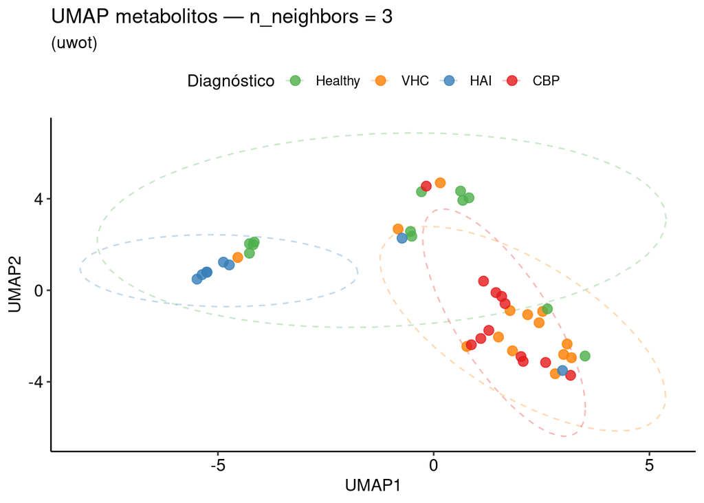

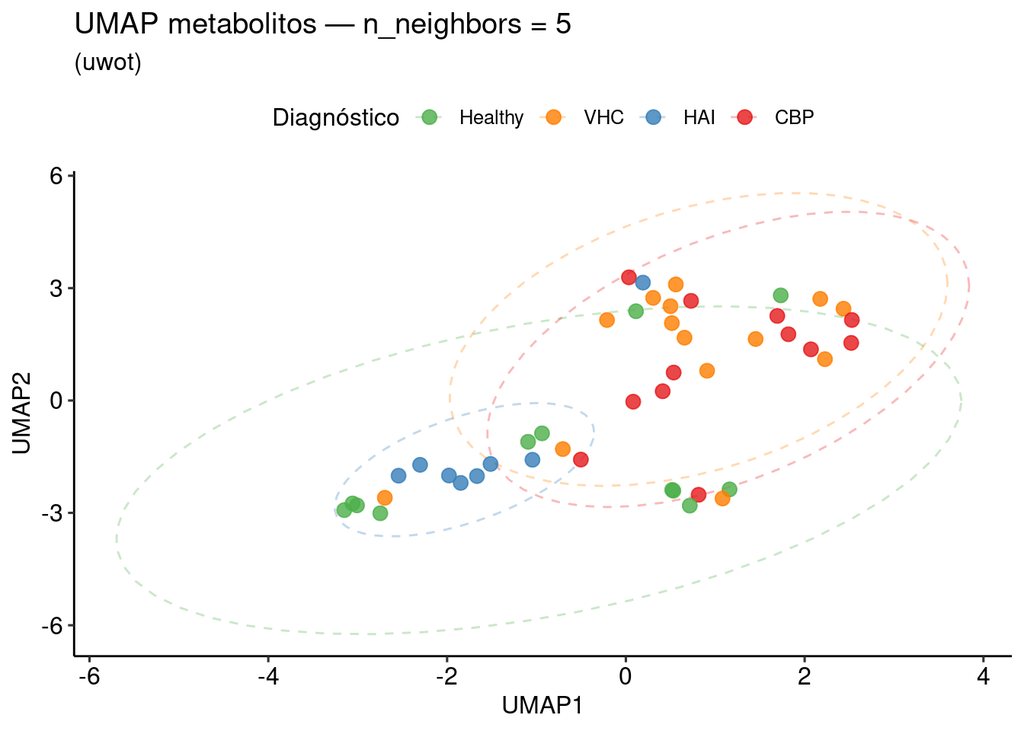

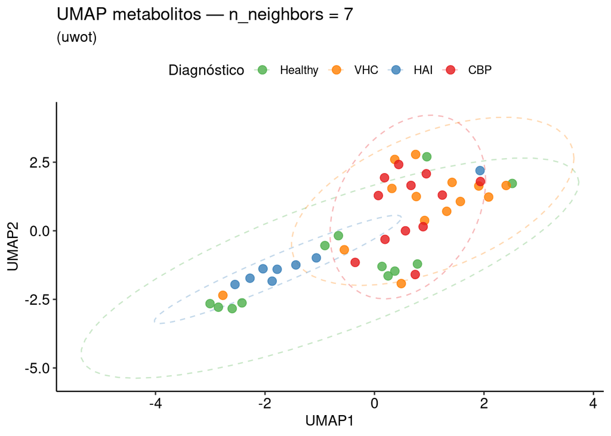

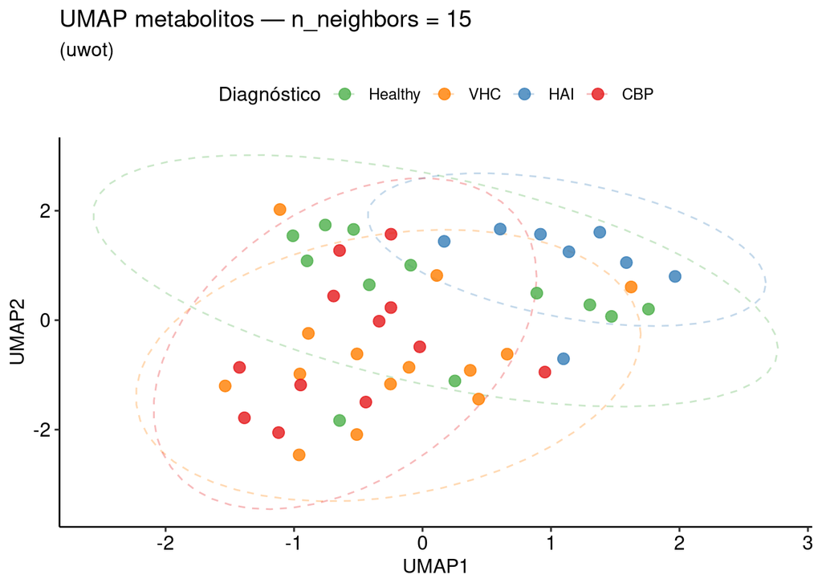

```r
set.seed(42)

# Probar distintos n_neighbors (por defecto 15, pero coge casi el 40% de pacientes)
for (nn in c(3, 5, 7, 15)) {
  set.seed(42)
  umap_res <- umap(mat_met,
                   n_neighbors = nn,
                   min_dist    = 0.1,
                   metric      = "euclidean")

  df_umap <- data.frame(
    UMAP1       = umap_res[, 1],
    UMAP2       = umap_res[, 2],
    diagnostico = factor(datos_clinicos_metabolomicos$diagnostico_principal)
  )

  #Elipse con alpha detrás de los puntos
  p <- ggplot(df_umap, aes(x = UMAP1, y = UMAP2, color = diagnostico)) +
    stat_ellipse(aes(group = diagnostico), type = "t",
                 linetype = "dashed", linewidth = 0.5, alpha = 0.3) +
    geom_point(size = 3, alpha = 0.8) +
    scale_color_manual(values = paleta_dx) +
    theme_pubr() +
    labs(title    = paste0("UMAP metabolitos — n_neighbors = ", nn),
         subtitle = "(uwot)",
         color    = "Diagnóstico")
  print(p)
}
```

La optimización del hiperparámetro *n_neighbors* en el análisis **UMAP** de metabolitos demuestra de forma robusta la existencia de subestructuras no lineales dentro de la población, actuando el valor **n_neighbors = 3** como el ajuste óptimo del estudio. Con este valor bajo de vecindad, el algoritmo maximiza la sensibilidad hacia las relaciones locales y desvela un patrón de agrupamiento donde los pacientes con **HAI** forman un clúster compacto y aislado en el espacio izquierdo, mientras que **VHC y CBP** vuelven a manifestar su estrecha similitud metabólica al co-localizarse en un macro-clúster disperso hacia la derecha. A medida que este parámetro se incrementa progresivamente (5, 7 y 15), el modelo prioriza la estructura global sobre las distancias locales individuales, lo que provoca una pérdida paulatina de la resolución de los grupos y difumina las elipses de confianza en un solapamiento continuo similar al del PCA. Este comportamiento dinámico valida que la firma metabólica de la **HAI posee una identidad local única y diferenciada** que solo los modelos de alta resolución geométrica logran capturar por completo.

## Análisis t-SNE de metabolitos

En este apartado se utiliza **t-SNE** para proyectar los metabolitos en un espacio bidimensional no lineal, con el objetivo de visualizar posibles agrupamientos asociados al diagnóstico clínico.

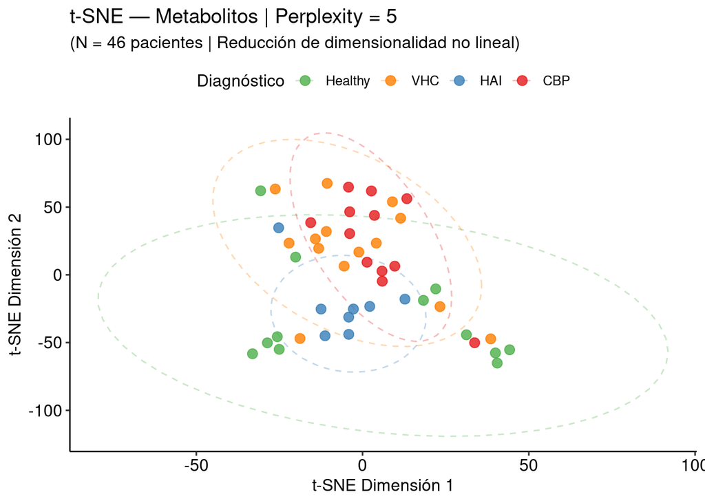

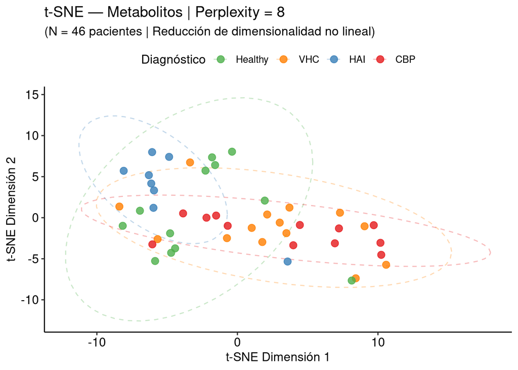

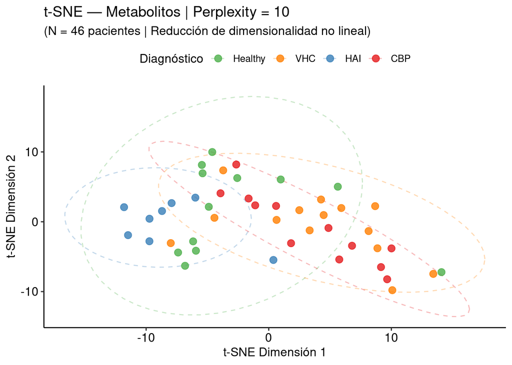

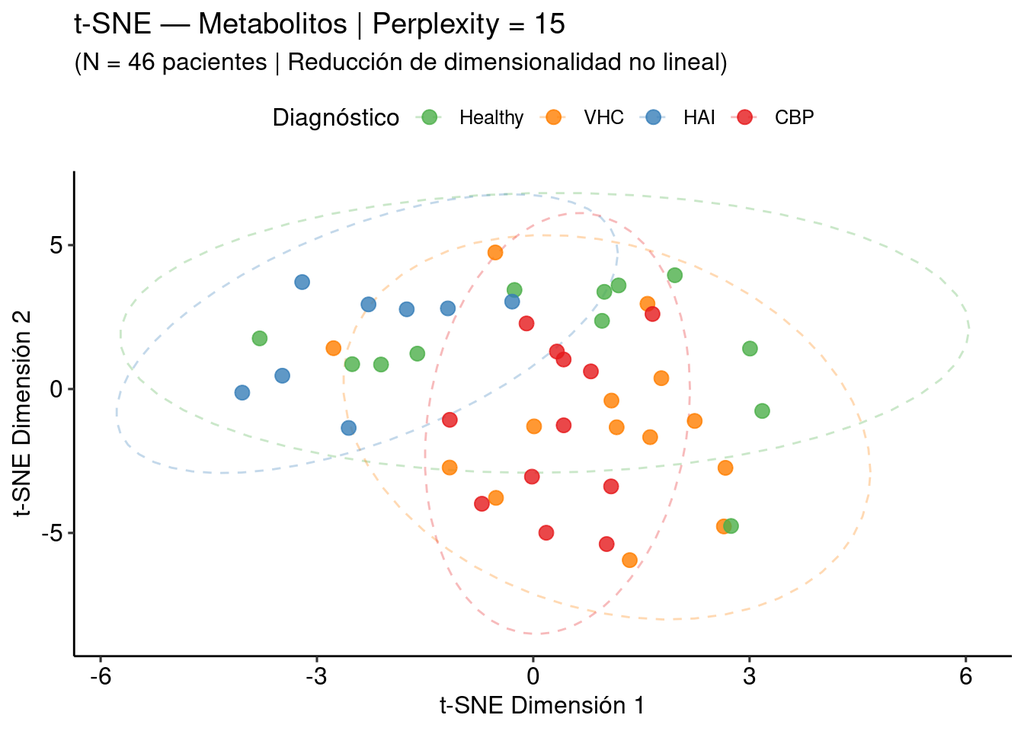

```r
set.seed(42)

# Probamos exclusivamente los valores válidos y óptimos para tu cohorte (literatura)
for (perp in c(5, 8, 10, 15)) {

  # Ejecución de t-SNE adaptando la perplejidad de forma dinámica
  tsne_met <- Rtsne(mat_met,
                    perplexity       = perp,  # Cambia en cada vuelta del ciclo
                    dims             = 2,
                    max_iter         = 1000,
                    check_duplicates = FALSE)

  # Construcción del dataframe temporal para esta iteración
  df_tsne_met <- data.frame(
    tSNE1       = tsne_met$Y[, 1],
    tSNE2       = tsne_met$Y[, 2],
    diagnostico = factor(datos_clinicos_metabolomicos$diagnostico_principal)
  )

  # Generación del gráfico adaptando el título y subtítulo al valor de 'perp'
  p <- ggplot(df_tsne_met, aes(x = tSNE1, y = tSNE2, color = diagnostico)) +
    stat_ellipse(aes(group = diagnostico), type = "t",
                 linetype = "dashed", linewidth = 0.5, alpha = 0.3) +
    geom_point(size = 3, alpha = 0.8) +
    scale_color_manual(values = paleta_dx) +
    theme_pubr() +
    labs(title    = paste0("t-SNE — Metabolitos | Perplexity = ", perp),
         subtitle = paste0("(N = 46 pacientes | Reducción de dimensionalidad no lineal)"),
         x        = "t-SNE Dimensión 1",
         y        = "t-SNE Dimensión 2",
         color    = "Diagnóstico")

  print(p)
}
```

El análisis de los gráficos demuestra que **t-SNE tiende a la homogeneización y no logra establecer fronteras limpias** entre las hepatopatías, independientemente de la configuración utilizada. Con valores bajos (Perplexity = 5 - 8), el algoritmo genera agrupaciones locales dispersas y artificiales que fragmentan las muestras sin una lógica patológica aparente. Al avanzar hacia valores moderados (Perplexity = 10- 15), el modelo estabiliza la estructura global distribuyendo a los pacientes con **VHC y CBP** de forma solapada por todo el espacio, mientras que **HAI** y los controles **Healthy** exhiben una sutil tendencia a agruparse en los cuadrantes izquierdos e inferiores, aunque manteniéndose encerrados bajo elipses de confianza masivas y superpuestas.

Este comportamiento dinámico ratifica que la topología de los datos metabolómicos no se adapta bien a las restricciones de t-SNE, confirmando que este método difumina la especificidad patológica que otros enfoques (como UMAP) sí logran capturar.

# **Variables clínicas**

Después, se estandarizan las variables clínicas numéricas y categóricas y se calcula la **distancia de Gower para integrar datos mixtos**. A partir de esta matriz se evalúan las diferencias entre grupos clínicos mediante **PERMANOVA**.

```r
# scale() dentro de mutate necesita as.numeric() para devolver vector en lugar de matriz, que es lo que daisy() requiere

df_clinica_gower <- datos_clinicos_metabolomicos %>%
  select(all_of(vars_num), all_of(vars_cat)) %>%
  mutate(across(all_of(vars_num), ~ as.numeric(scale(.)))) %>%
  mutate(across(all_of(vars_cat), as.factor))

# Verificar tipos de columna antes de daisy
cat("Tipos de columnas (primeras 5):\n")
```

```
## Tipos de columnas (primeras 5):
```

```r
print(sapply(df_clinica_gower[, 1:5], class))
```

```
##          idade   tempo_mostra   a1_final_mm2 a2_inicial_mm2    media_a1_a2
##      "numeric"      "numeric"      "numeric"      "numeric"      "numeric"
```

```r
dist_gower <- daisy(df_clinica_gower, metric = "gower")
cat("Rango distancia Gower:", range(as.matrix(dist_gower)), "\n")
```

```
## Rango distancia Gower: 0 0.420592
```

```r
# PERMANOVA clínica (Gower)
set.seed(123)
permanova_clin <- adonis2(dist_gower ~ diagnostico_principal,
                          data         = datos_clinicos_metabolomicos,
                          permutations = 999)
cat("=== PERMANOVA Clínica (Gower, escalado) ===\n")
```

```
## === PERMANOVA Clínica (Gower, escalado) ===
```

```r
print(permanova_clin)
```

```
## Permutation test for adonis under reduced model
## Permutation: free
## Number of permutations: 999
##
## adonis2(formula = dist_gower ~ diagnostico_principal, data = datos_clinicos_metabolomicos, permutations = 999)
##          Df SumOfSqs      R2      F Pr(>F)
## Model     3  0.31906 0.25065 4.6829  0.001 ***
## Residual 42  0.95386 0.74935
## Total    45  1.27291 1.00000
## ---
## Signif. codes:  0 '***' 0.001 '**' 0.01 '*' 0.05 '.' 0.1 ' ' 1
```

El análisis mediante **PERMANOVA** con distancia de Gower revela que el perfil clínico diferencia de forma muy potente y estadísticamente significativa a los grupos diagnósticos (p = 0.001), demostrando que la patología explica un sólido **25.07% de la variabilidad total** de los datos (R^2 = 0.251). Este tamaño del efecto es metodológicamente el más elevado de todo el estudio multiómico, superando al 15.63% de la metabolómica y al 5.75% de la microbiota. De este modo, los **datos clínicos se consolidan como el conjunto de variables con mayor fuerza de asociación y capacidad de separación biológica para discriminar entre las diferentes hepatopatías de la cohorte**.

## Visualización UMAP de variables clínicas

En este apartado se proyectan las variables clínicas mediante **UMAP basado en la distancia de Gower**, explorando la estructura de los pacientes y evaluando la estabilidad del resultado con distintos números de vecinos.

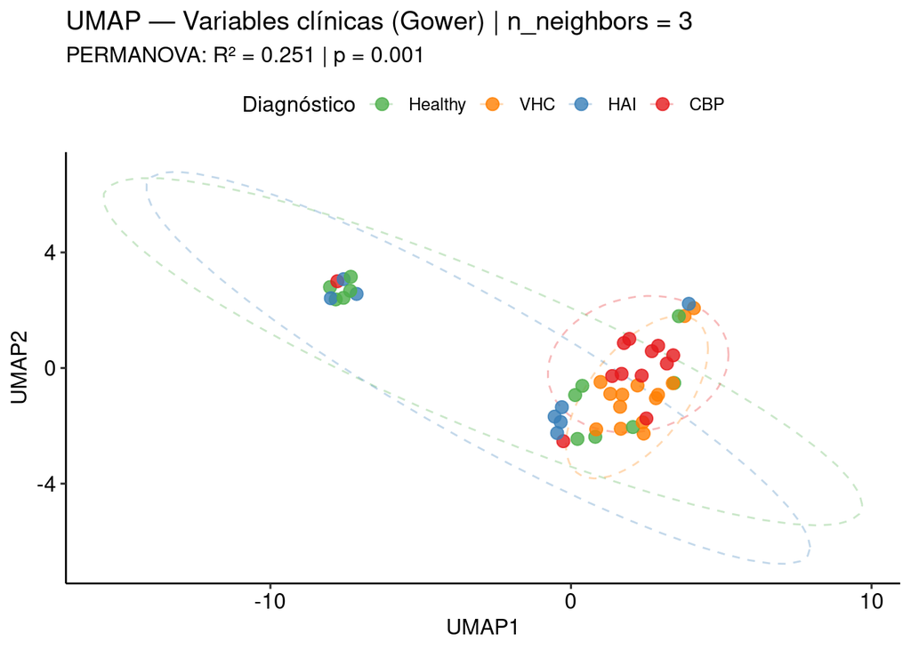

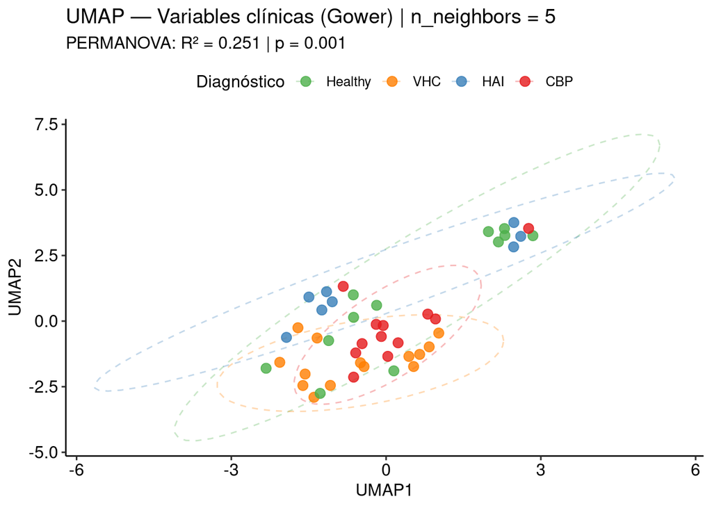

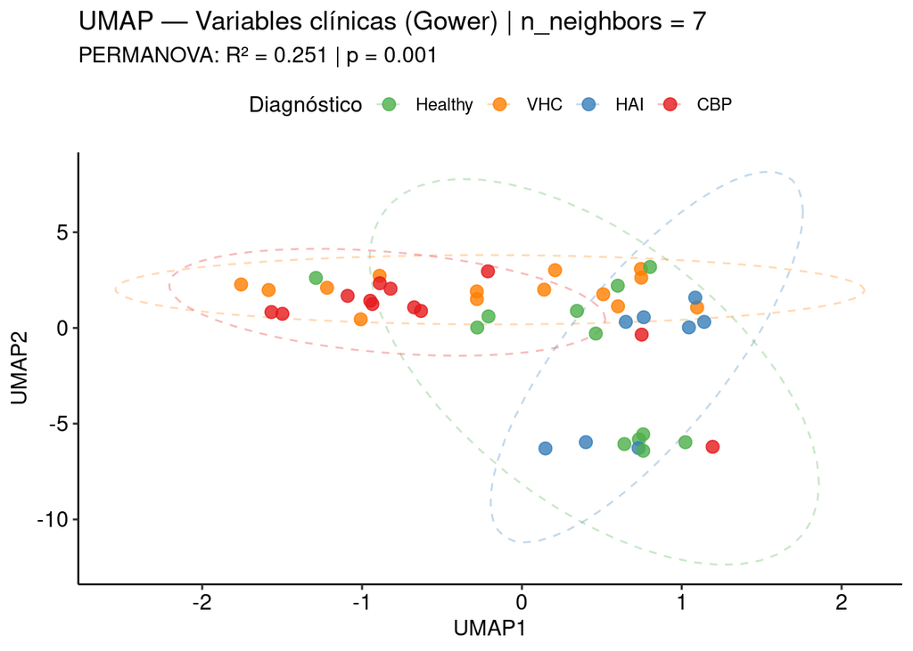

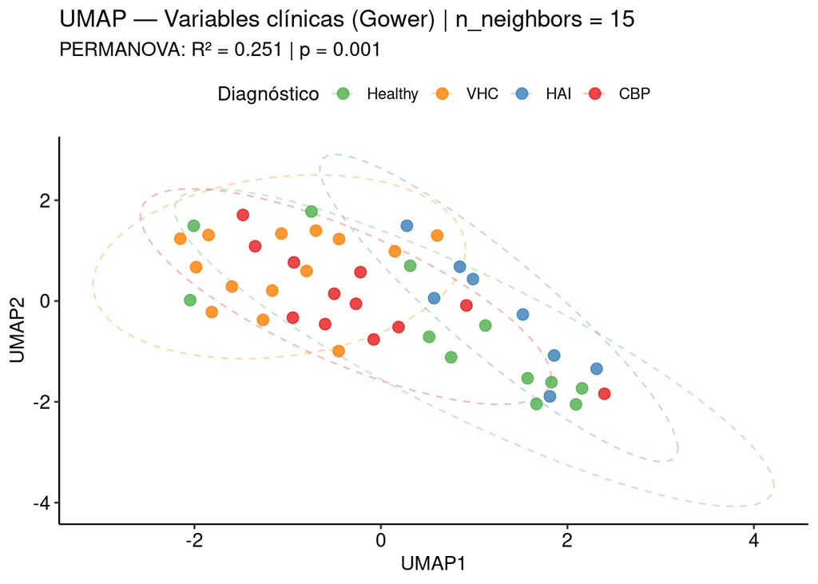

```r
set.seed(42)

# Convertimos la matriz de Gower en un objeto de clase 'dist' nativo de R.
# Esto le avisa a uwot de forma automática que NO use el motor Annoy.
dist_gower_objeto <- as.dist(dist_gower)

# Probamos los valores 3, 5, 7 y 15 neighbors de forma secuencial
for (nn in c(3, 5, 7, 15)) {

  # Al pasar un objeto 'dist', quitamos el argumento metric = "precomputed"
  umap_gower <- umap(dist_gower_objeto,
                     n_neighbors = nn,
                     min_dist    = 0.1)

  # Construcción del dataframe temporal para esta iteración
  df_umap_gower <- data.frame(
    UMAP1       = umap_gower[, 1],
    UMAP2       = umap_gower[, 2],
    diagnostico = factor(datos_clinicos_metabolomicos$diagnostico_principal)
  )

  # Generación del gráfico dinámico con la paleta correspondiente
  p <- ggplot(df_umap_gower, aes(x = UMAP1, y = UMAP2, color = diagnostico)) +
    stat_ellipse(aes(group = diagnostico), type = "t",
                 linetype = "dashed", linewidth = 0.5, alpha = 0.3) +
    geom_point(size = 3, alpha = 0.8) +
    scale_color_manual(values = paleta_dx) +
    theme_pubr() +
    labs(title    = paste0("UMAP — Variables clínicas (Gower) | n_neighbors = ", nn),
         subtitle = paste0("PERMANOVA: R² = ", round(permanova_clin$R2[1], 3),
                           " | p = ", permanova_clin$`Pr(>F)`[1]),
         color    = "Diagnóstico")

  print(p)
}
```

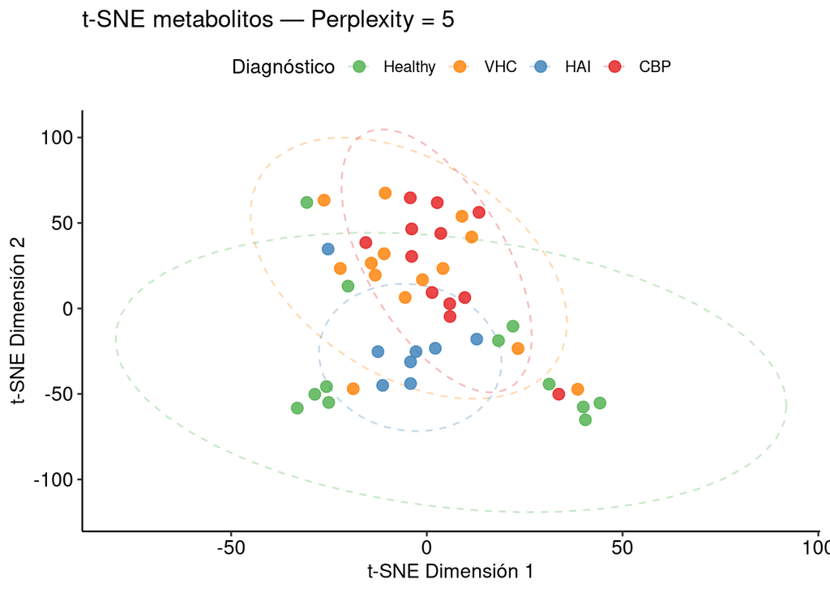

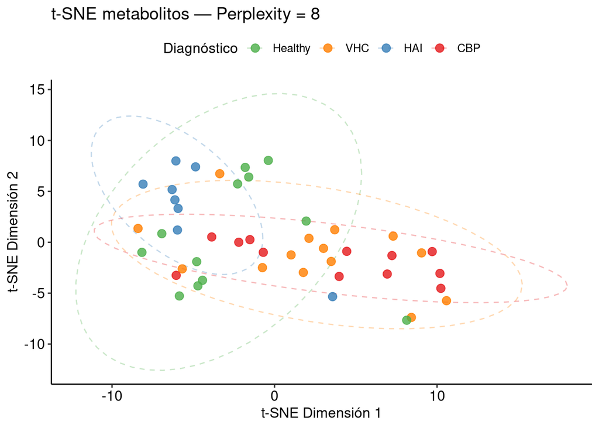

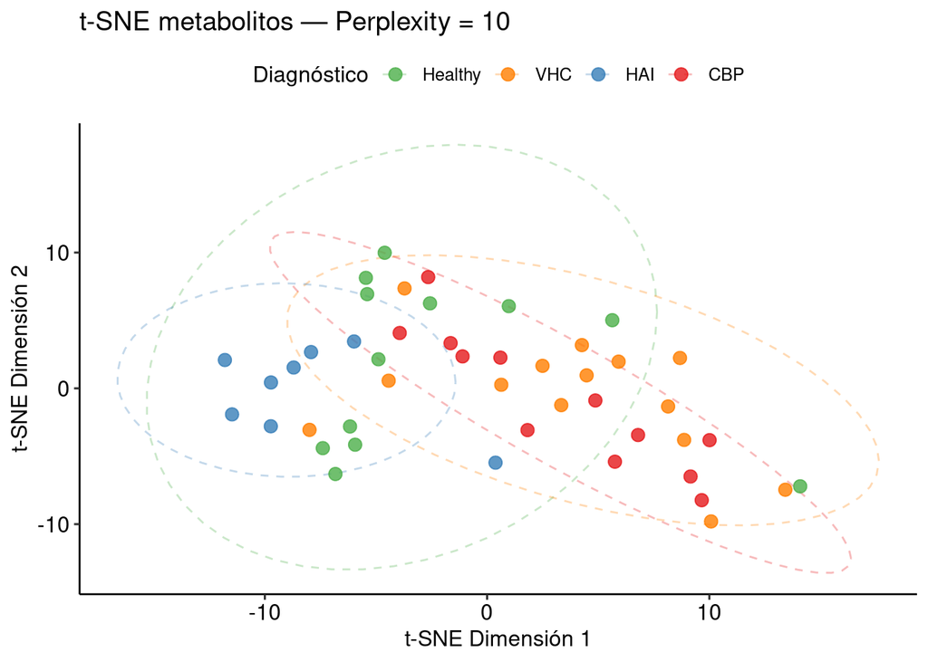

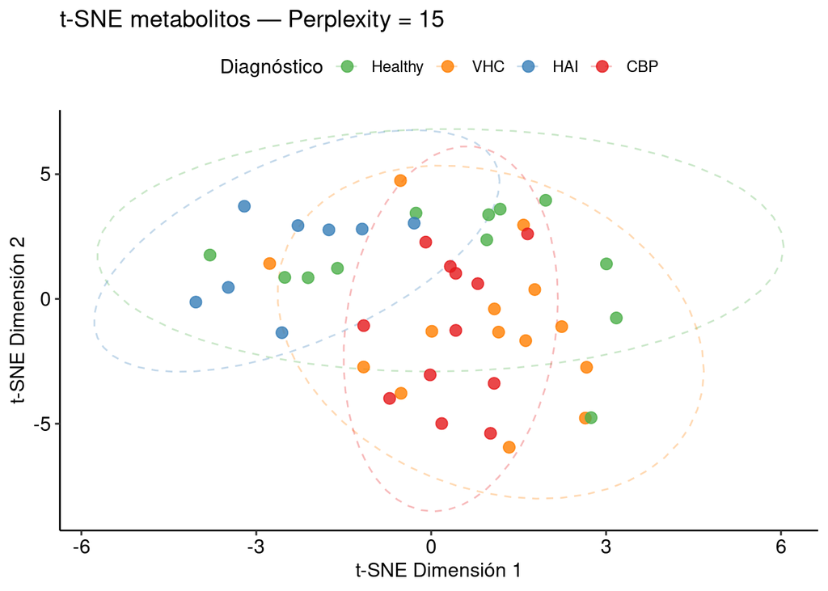

```r
set.seed(42)

# Se prueban valores válidos y óptimos para N = 46
for (perp in c(5, 8, 10, 15)) {

  # Ejecución de t-SNE sobre tu matriz de metabolitos
  tsne_res <- Rtsne(mat_met,
                    perplexity = perp,
                    check_duplicates = FALSE,
                    pca = TRUE) # Mantiene la reducción de ruido por PCA previa

  # Construcción del dataframe compatible con las etiquetas clínicas
  df_tsne <- data.frame(
    tSNE1       = tsne_res$Y[, 1],
    tSNE2       = tsne_res$Y[, 2],
    diagnostico = factor(datos_clinicos_metabolomicos$diagnostico_principal)
  )

  # Gráfico final con elipses y paleta_dx
  p <- ggplot(df_tsne, aes(x = tSNE1, y = tSNE2, color = diagnostico)) +
    stat_ellipse(aes(group = diagnostico), type = "t",
                 linetype = "dashed", linewidth = 0.5, alpha = 0.3) +
    geom_point(size = 3, alpha = 0.8) +
    scale_color_manual(values = paleta_dx) +
    theme_pubr() +
    labs(title    = paste0("t-SNE metabolitos — Perplexity = ", perp),
         x        = "t-SNE Dimensión 1",
         y        = "t-SNE Dimensión 2",
         color    = "Diagnóstico")

  print(p)
}
```

# **HEATMAPs**

## Heatmap de metabolitos basado en PCA

Después, se seleccionan los metabolitos con mayor contribución a los componentes principales del PCA y se construye un heatmap para visualizar sus patrones de abundancia entre muestras, incorporando anotación por diagnóstico.

```r
#Heatmap con variables más importantes del PCA (top contribuyentes a PC1 y PC2, no todas las variables)

contrib_pc1 <- pca_met$var$contrib[, 1]
contrib_pc2 <- pca_met$var$contrib[, 2]

top_pc1 <- names(sort(contrib_pc1, decreasing = TRUE))[1:15]
top_pc2 <- names(sort(contrib_pc2, decreasing = TRUE))[1:15]
top_vars_pca <- unique(c(top_pc1, top_pc2))

cat("Variables seleccionadas para heatmap:", length(top_vars_pca), "\n")
```

```
## Variables seleccionadas para heatmap: 27
```

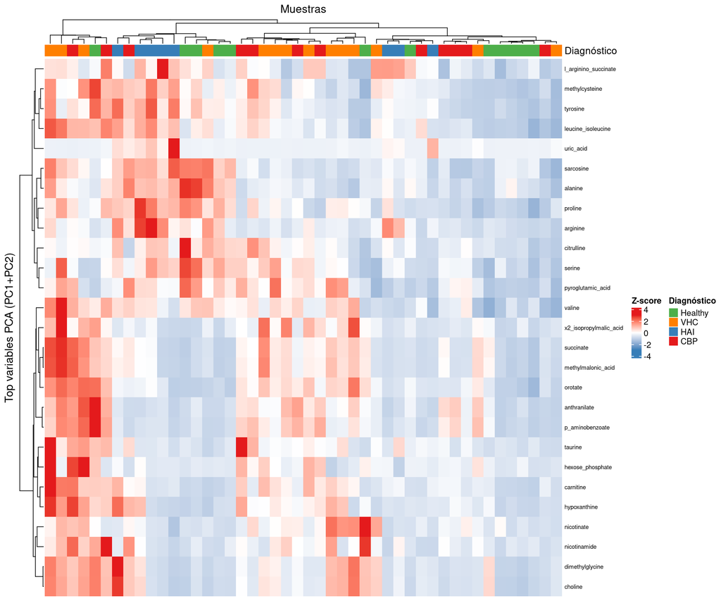

```r
# Matriz escalada con solo esas variables
mat_hm_top <- t(scale(as.matrix(
  datos_clinicos_metabolomicos[, top_vars_pca]
)))
colnames(mat_hm_top) <- datos_clinicos_metabolomicos$Sample

col_anno <- HeatmapAnnotation(
  Diagnóstico = datos_clinicos_metabolomicos$diagnostico_principal,
  col         = list(Diagnóstico = paleta_dx),
  annotation_legend_param = list(
    Diagnóstico = list(title = "Diagnóstico")
  )
)

col_fun <- colorRamp2(c(-3, 0, 3),
                      c("#377EB8", "white", "#E41A1C"))

Heatmap(mat_hm_top,
        name                      = "Z-score",
        col                       = col_fun,
        top_annotation            = col_anno,
        clustering_method_rows    = "ward.D2",
        clustering_method_columns = "ward.D2",
        show_column_names         = FALSE,
        show_row_names            = TRUE,
        row_names_gp              = gpar(fontsize = 7),
        column_title              = "Muestras",
        row_title                 = "Top variables PCA (PC1+PC2)",
        heatmap_legend_param      = list(title = "Z-score"))
```

## Heatmap clínico integrado (variables numéricas y categóricas)

En este apartado se seleccionan variables clínicas relevantes mediante PCA y V de Cramer, y se integran en un heatmap conjunto que permite relacionar patrones multivariantes con los distintos grupos de diagnóstico.

```r
# HEATMAP VARIABLES CLÍNICAS — top PCA

# SELECCIÓN ESTADÍSTICA E INTEGRACIÓN EN HEATMAP CLÍNICO

# 1. Crear un data frame vacío para guardar los resultados de las 80 variables
resultados_cat <- data.frame(Variable = character(), Cramer_V = numeric(), stringsAsFactors = FALSE)

# 2. Correr el bucle para calcular la V de Cramér de cada variable vs el Diagnóstico
for (var in vars_cat) {
  tabla <- table(datos_clinicos_metabolomicos[[var]], datos_clinicos_metabolomicos$diagnostico_principal)

  tryCatch({
    stat_res <- vcd::assocstats(tabla)
    cramer_v <- stat_res$cramer
    if(!is.na(cramer_v)) {
      resultados_cat <- rbind(resultados_cat, data.frame(Variable = var, Cramer_V = cramer_v))
    }
  }, error = function(e) { NULL })
}

# 3. Ordenar las variables de mayor a menor asociación y elegir las TOP 5
top_variables_estadisticas <- resultados_cat %>%
  arrange(desc(Cramer_V)) %>%
  slice_head(n = 5) %>%
  pull(Variable)

cat("Las variables categóricas seleccionadas matemáticamente son:\n")
```

```
## Las variables categóricas seleccionadas matemáticamente son:
```

```r
print(top_variables_estadisticas)
```

```
## [1] "anti_vhc_1"            "ama_1"                 "Tipo órgano_Demi"
## [4] "Tipo órgano_Nentunian" "plasmocitos_em_ep_1"
```

```r
# 4. Preparar el data frame de anotaciones con las variables seleccionadas
df_anotaciones_cat <- datos_clinicos_metabolomicos %>%
  select(diagnostico_principal, all_of(top_variables_estadisticas)) %>%
  as.data.frame()

rownames(df_anotaciones_cat) <- datos_clinicos_metabolomicos$Sample


# 5. ASIGNACIÓN AUTOMÁTICA DE COLORES ELEGANTES (RColorBrewer)
# Iniciamos la lista de colores con tu paleta fija de diagnóstico
lista_colores_elegantes <- list(diagnostico_principal = paleta_dx)

# Extraemos colores estéticos pasteles para las variables categóricas seleccionadas
colores_pastel <- brewer.pal(12, "Set3") # Una paleta muy elegante para categorías
contador_color <- 1

for (nom_var in top_variables_estadisticas) {
  # Buscamos qué grupos únicos tiene esta variable
  grupos_unicos <- unique(na.omit(df_anotaciones_cat[[nom_var]]))
  n_grupos      <- length(grupos_unicos)

  # Tomamos un subconjunto de colores para estos grupos
  colores_asignados <- colores_pastel[contador_color:(contador_color + n_grupos - 1)]
  names(colores_asignados) <- grupos_unicos

  # Guardamos la paleta para esta variable específica
  lista_colores_elegantes[[nom_var]] <- colores_asignados

  # Avanzamos el contador para que la siguiente variable use colores distintos
  contador_color <- contador_color + n_grupos
}


# 6. Construir la anotación superior con la nueva lista de colores
col_anno <- HeatmapAnnotation(
  df  = df_anotaciones_cat,
  col = lista_colores_elegantes,
  annotation_name_gp = gpar(fontsize = 8, fontface = "bold")
)

# 7. PCA de variables clínicas numéricas (escaladas)
mat_clin_scaled <- scale(as.matrix(
  datos_clinicos_metabolomicos[, vars_num]
))
rownames(mat_clin_scaled) <- datos_clinicos_metabolomicos$Sample

pca_clin <- PCA(mat_clin_scaled, graph = FALSE, ncp = 10)

# Top variables contribuyentes a PC1 y PC2
contrib_clin_pc1 <- pca_clin$var$contrib[, 1]
contrib_clin_pc2 <- pca_clin$var$contrib[, 2]
top_clin_pc1 <- names(sort(contrib_clin_pc1, decreasing = TRUE))[1:12]
top_clin_pc2 <- names(sort(contrib_clin_pc2, decreasing = TRUE))[1:12]
top_vars_clin_pca <- unique(c(top_clin_pc1, top_clin_pc2))

mat_hm_clin_pca <- t(scale(as.matrix(
  datos_clinicos_metabolomicos[, top_vars_clin_pca]
)))
colnames(mat_hm_clin_pca) <- datos_clinicos_metabolomicos$Sample

col_fun <- colorRamp2(c(-3, 0, 3), c("#377EB8", "white", "#E41A1C"))


# 8. DIBUJAR EL HEATMAP FINAL
pdf("Heatmap_Clinico_Top_PCA_y_Categoricas.pdf", width = 12, height = 10)

Heatmap(mat_hm_clin_pca,
        name                      = "Z-score",
        col                       = col_fun,
        top_annotation            = col_anno,
        clustering_method_rows    = "ward.D2",
        clustering_method_columns = "ward.D2",
        show_column_names         = FALSE,
        show_row_names            = TRUE,
        row_names_gp              = gpar(fontsize = 7),
        column_title              = "Muestras",
        row_title                 = "Variables clínicas — top PCA (PC1+PC2)",
        heatmap_legend_param      = list(title = "Z-score"))

dev.off()
```

## Heatmap de bacterias (CLR + PCA)

Finalmente, se filtran géneros bacterianos según prevalencia y abundancia, se aplica una transformación CLR para corregir sesgos composicionales y se seleccionan los taxones más relevantes mediante PCA para su representación comparativa entre grupos clínicos.

```r
# HEATMAP BACTERIAS — top PCA (Utilizando CLR)

# 1. Filtrar géneros prevalentes y abundantes sobre abundancia relativa
prevalencia  <- rowMeans(assay(tse_genus, "relabundance") > 0)
abund_media  <- rowMeans(assay(tse_genus, "relabundance"))
generos_filt <- names(which(prevalencia >= 0.2 & abund_media >= 0.001))

# Filtrar el objeto original con los géneros seleccionados
tse_genus_filt <- tse_genus[generos_filt, ]

# 2. Calcular la transformación CLR clásica sobre el objeto filtrado
# CORRECCIÓN: Cambiado pseudocount = TRUE por pseudocount = 1 (Estándar de mia)
tse_genus_filt <- transformAssay(tse_genus_filt,
                                 assay.type  = "counts",
                                 method      = "clr",
                                 pseudocount = 1)

# Extraer la matriz CLR (muestras en filas, bacterias en columnas)
mat_bact_clr <- t(assay(tse_genus_filt, "clr"))

# 3. Alinear con muestras del dataset clínico
muestras_comun <- intersect(rownames(mat_bact_clr), datos_clinicos_metabolomicos$Sample)
mat_bact_al <- mat_bact_clr[muestras_comun, ]

# 4. PCA sobre bacterias usando la matriz de composición CLR pura
mat_bact_scaled <- scale(mat_bact_al)
pca_bact <- PCA(mat_bact_scaled, graph = FALSE, ncp = 10)

# Extraer los taxones que más varían/contribuyen en los dos primeros componentes
contrib_bact_pc1 <- pca_bact$var$contrib[, 1]
contrib_bact_pc2 <- pca_bact$var$contrib[, 2]
top_bact_pc1     <- names(sort(contrib_bact_pc1, decreasing = TRUE))[1:15]
top_bact_pc2     <- names(sort(contrib_bact_pc2, decreasing = TRUE))[1:15]
top_vars_bact_pca <- unique(c(top_bact_pc1, top_bact_pc2))

cat("Géneros seleccionados por PCA (CLR):", length(top_vars_bact_pca), "\n")
```

```
## Géneros seleccionados por PCA (CLR): 24
```

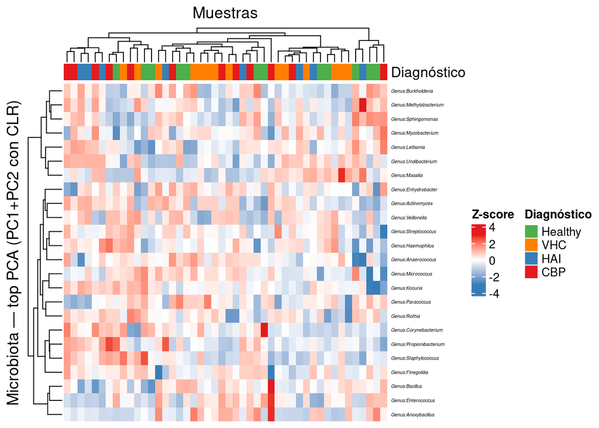

```r
# 5. Configurar datos para el Heatmap Visual
idx_muestras <- match(muestras_comun, datos_clinicos_metabolomicos$Sample)

# Para la representación visual aplicamos Z-score sobre los valores CLR seleccionados
mat_hm_bact_pca <- t(scale(mat_bact_al[, top_vars_bact_pca]))
colnames(mat_hm_bact_pca) <- muestras_comun

# Definir la función de color divergente (Azul = bajo / Blanco = media / Rojo = alto)
col_fun <- colorRamp2(c(-3, 0, 3), c("#377EB8", "white", "#E41A1C"))

# Crear la barra de anotación superior (Diagnóstico)
col_anno_bact <- HeatmapAnnotation(
  Diagnóstico = datos_clinicos_metabolomicos$diagnostico_principal[idx_muestras],
  col = list(Diagnóstico = paleta_dx)
)

# Dibujar el Heatmap final (CORRECCIÓN: Se cerraron los paréntesis correctamente)
Heatmap(mat_hm_bact_pca,
        name                      = "Z-score",
        col                       = col_fun,
        top_annotation            = col_anno_bact,
        clustering_method_rows    = "ward.D2",
        clustering_method_columns = "ward.D2",
        show_column_names         = FALSE,
        show_row_names            = TRUE,
        row_names_gp              = gpar(fontsize = 4, fontface = "italic"),
        column_title              = "Muestras",
        row_title                 = "Microbiota — top PCA (PC1+PC2 con CLR)",
        heatmap_legend_param      = list(title = "Z-score"))
```

Este *heatmap* representa la abundancia relativa (escala Z-score tras una transformación CLR) de los **géneros bacterianos** más representativos derivados de un análisis de componentes principales (PCA), organizando jerárquicamente tanto las muestras (columnas) como los taxones (filas). A diferencia de los perfiles metabólicos y clínicos previos, el dendrograma superior revela una **menor separación o agrupamiento neto** basado estrictamente en el `Diagnóstico` (Sano en verde, VHC en naranja, HAI en azul y CBP en rojo), mostrando una distribución mucho más entremezclada de los grupos patológicos y los controles a lo largo del eje horizontal. A pesar de esta heterogeneidad general, se aprecian subgrupos específicos con firmas de disbiosis interesantes; por ejemplo, un bloque de pacientes con CBP y HAI hacia el extremo derecho exhibe una marcada depleción (tonos azules intensos) de géneros comensales o ambientales comunes como *Streptococcus*, *Haemophilus*, *Anaerococcus* y *Micrococcus*, mientras que ciertos géneros como *Corynebacterium*, *Propionibacterium* y *Staphylococcus* muestran picos de sobreabundancia (tonos rojos) localizados en muestras patológicas específicas, sugiriendo que las alteraciones de la microbiota hepática o sistémica en estas enfermedades son más sutiles, heterogéneas y variables entre individuos que sus respuestas metabólicas y clínicas.